# Denetimli İstatistiksel Öğrenme Ara Sınav

Fatih Emre Öztürk | 2021900444

2022-12-04

```r
df <- Wage
```

## Veri Seti Bilgisi

Veri setinde 3000 gözlem 11 değişken bulunmaktadır. Veri setinde yer alan değişkenlerin bilgisi ise aşağıdaki tablodaki gibidir:

| Değişken İsmi | Anlamı |
| --- | --- |
| Year | Maaş bilgisinin edinildiği yıl |
| Age | İşçinin yaşı |
| Maritl | Medeni durum |
| Race | İşçinin ırkı |
| Region | Ülkenin bölgesi |
| Jobclass | İşin tipi ile ilgili endüstriyel bilgi |
| Health | İşçinin sağlık durumu |
| Health_ins | İşçinin sağlık sigortası |
| Logwage | İşçilerin maaşının logaritması |
| Wage | İşçilerin maaşı |

## Test-Train Ayrımı

```r
smp_size <- floor(0.75 * nrow(df))
set.seed(2021900444)
train_ind <- sample(nrow(df), size = smp_size, replace = FALSE)
train <- df[train_ind, ]
test <- df[-train_ind, ]
```

## Tanımlayıcı İstatistikler

```
##       year           age                     maritl           race
##  Min.   :2003   Min.   :18.00   1. Never Married: 485   1. White:1846
##  1st Qu.:2004   1st Qu.:34.00   2. Married      :1549   2. Black: 228
##  Median :2006   Median :42.00   3. Widowed      :  17   3. Asian: 149
##  Mean   :2006   Mean   :42.54   4. Divorced     : 155   4. Other:  27
##  3rd Qu.:2008   3rd Qu.:51.00   5. Separated    :  44
##  Max.   :2009   Max.   :80.00
##
##               education                     region               jobclass
##  1. < HS Grad      :204   2. Middle Atlantic   :2250   1. Industrial :1165
##  2. HS Grad        :738   1. New England       :   0   2. Information:1085
##  3. Some College   :473   3. East North Central:   0
##  4. College Grad   :521   4. West North Central:   0
##  5. Advanced Degree:314   5. South Atlantic    :   0
##                           6. East South Central:   0
##                           (Other)              :   0
##             health      health_ins      logwage           wage
##  1. <=Good     : 658   1. Yes:1578   Min.   :3.000   Min.   : 20.09
##  2. >=Very Good:1592   2. No : 672   1st Qu.:4.447   1st Qu.: 85.38
##                                      Median :4.653   Median :104.92
##                                      Mean   :4.652   Mean   :111.64
##                                      3rd Qu.:4.857   3rd Qu.:128.68
##                                      Max.   :5.763   Max.   :318.34
##
```

**Sayısal değişkenlerin tanımlayıcı istatistikleri incelendiğinde:**

- Year değişkeninin range’inin oldukça düşük(6) olduğu dikkat çekmektedir. Sayısal olmasına rağmen kategorik davrandığı fark edilmiştir. Bu sebeple bu değişkeni kategorikleştirmek düşünülebilir.
- Age değişkeninin mean ile medyanı birbirine oldukça yakın çıkmıştır.
- logwage değişkeninin tanımlayıcı istatistiği incelendiğinde mean ile median değerleri birbirine oldukça yakın olduğı, çarpıklığın yok denilebilecek kadar az olduğu fark edilmiştir.
- Wage değişeninin mean’i mediandan yüksek çıkmıştır. Bu sebeple sağa çarpık olabileceği düşünülmektedir. Ayrıca 1. kartil(85) ile min değer(20) değer arasındaki fark düşünüldüğünde aykırı değer olabileceği varsayılmaktadır. Boxplot analizi ile daha sağlıklı bir yorum yapmak mümkün olabilir.

**Kategorik değişkenlerin tanımlayıcı istatistikleri incelendiğinde:**

- Medeni durumu gösteren faktör değişkeninde çok fazla level olduğu fark edilmiştir.
- Grafik incelemesi sonrası bu seviyelerin düşürülüp düşürülmeyeceğine karar verilecektir.
- Irk bilgisini içeren değişkende Beyaz ırkının çokluğu dikkat çekmekle birlikte bölge bilgisini içeren değişkene bakıldığında anlaşılmıştır.
- Eğitim bilgisini içeren grafik incelendiğinde “Some College” level’ı anlaşılmamış, yarıda bırakmış olabileceği düşünülmektedir. Grafik incelemesi sonrası bu değişkenin levellerinde de değişikliğe gidilebileceği düşünülmektedir.
- Region değişkeninde Middle Atlantic dışında bir bilgi olmadığı fark edilmiştir. Başka seviye olmaması bu değişkenin hiçbir farklılık yaratmayacağını düşündürtmüştür. Bu sebeple bu değişkeni modele katmanın bir anlamı yoktur. Analiz sonucunda yapılacak olan tahmin yalnızca Middle Atlantic bölgesinde yaşayan işçiler için olacaktır.Bu sebeple bu değişken veri setinden çıkarılmıştır.
- Jobclas değişkeninin iki seviyesi olduğu, bu seviyelere sahip gözlem değerlerinin de birbirlerine oldukça yakın olduğu fark edilmiştir.
- Health değişkeninin seviyelerinde Very Good değişkeninin daha fazla gözlemi olduğu fark edilmiştir.
- Health Insurance değişkeni incelendiğinde işçilerin büyük bir çoğunluğunun sigortası olduğu fark edilmiştir.

### Sayısal Değişkenlerin Grafik Analizi

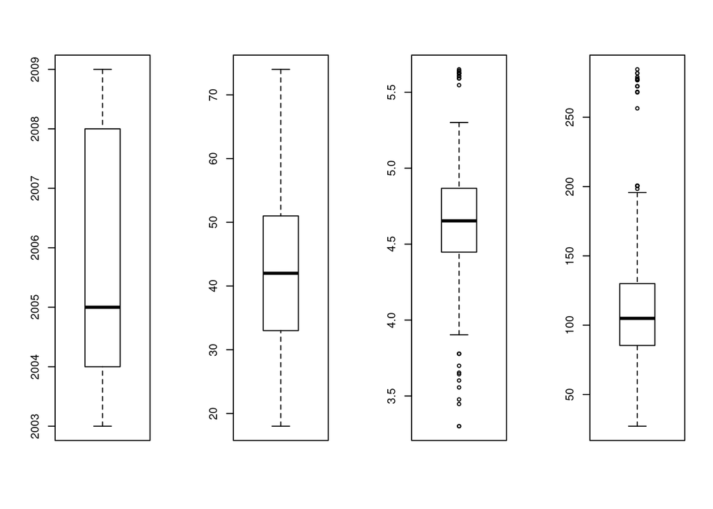

```r
par(mfrow = c(1,4))

boxplot(test$year)
boxplot(test$age)
boxplot(test$logwage)
boxplot(test$wage)
```

2. Logwage

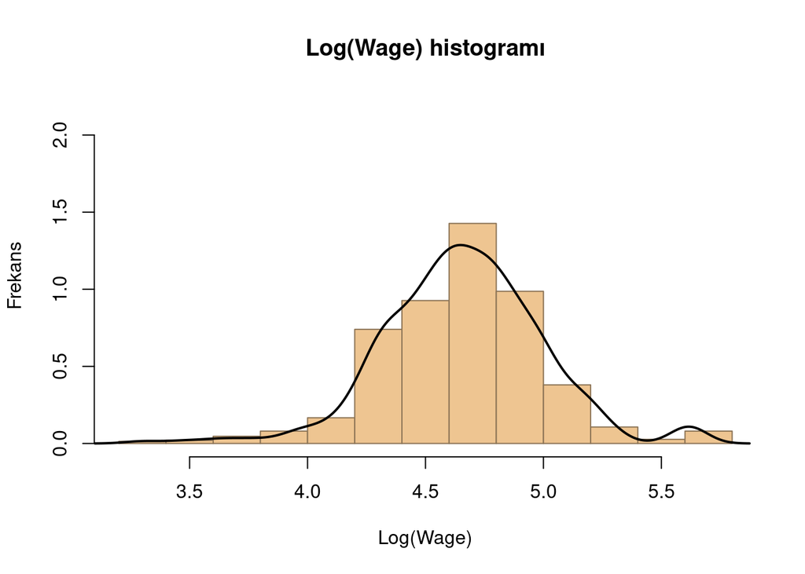

```r
fun <- dnorm(test$logwage, mean = mean(test$logwage), sd = sd(test$logwage))

hist(test$logwage, main = "Log(Wage) histogramı", ylab = "Frekans", xlab = "Log(Wage)",col="burlywood2",
     border="burlywood4", probability = T, ylim = c(0, max(fun) + 1))

lines(density(test$logwage), col = 9, lwd = 2)
```

Logwage değişkeninin iki tepeli olduğu histogram grafiğinden anlaşılmıştır. Sola çarpıklık da görülmektedir. Sola çarpıklık skewness(-0.12) ile de sağlanmıştır.

1.2 : Normallik Testleri

İki testin hipotezleri de aynı olduğu için hipotezler yalnızca bir kere gösterilmek istenilmiştir.

Ho : Logwage değişkeni normal dağılmıştır.

Ha : Logwage değişkeni normal dağılmamaktadır.

```r
ad.test(test$logwage)
```

```
##
##  Anderson-Darling normality test
##
## data:  test$logwage
## A = 2.2861, p-value = 8.516e-06
```

```r
shapiro.test(test$logwage)
```

```
##
##  Shapiro-Wilk normality test
##
## data:  test$logwage
## W = 0.98036, p-value = 1.714e-08
```

Logwage değişkeni için yapılan iki hipotez testinin p değerleri 0.05’ten küçük olduğu için %95 güvenle Ho: değişkenler normal dağılır hipotezini reddetmek için yeterli delile sahip olduğumuz çıkarımını yapmak mümkündür.

2. Wage

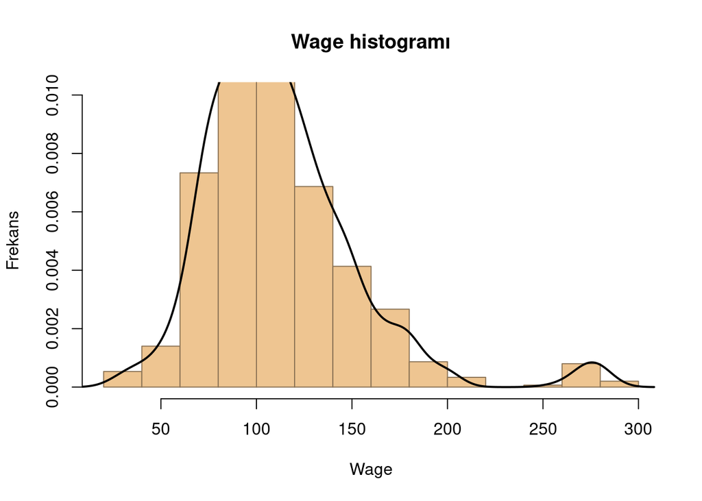

```r
fun <- dnorm(test$wage, mean = mean(test$wage), sd = sd(test$wage))

hist(test$wage, main = "Wage histogramı", ylab = "Frekans", xlab = "Wage",col="burlywood2",
     border="burlywood4", probability = T, ylim = c(0, max(fun)))

lines(density(test$wage), col = 9, lwd = 2)
```

Wage değişkeninin iki tepeli olduğu histogram grafiğinden anlaşılmıştır. Sağa çarpıklık da görülmektedir. Uç değer olarak da düşünebileceğimiz 250 ve fazlası değerler çıkarılırsa normallik sağlanabilir.

Ancak yine de normallik sınamaları ile daha sağlıklı bir yorum yapılmak istenilmiştir.

2.1 Normallik Testleri

İki testin(Anderson- Darling ve Shapiro-Wilks) hipotezleri de aynı olduğu için hipotezler yalnızca bir kere gösterilmek istenilmiştir.

Ho : wage değişkeni normal dağılmıştır.

Ha : wage değişkeni normal dağılmamaktadır.

```r
ad.test(test$wage)
```

```
##
##  Anderson-Darling normality test
##
## data:  test$wage
## A = 13.598, p-value < 2.2e-16
```

```r
shapiro.test(test$wage)
```

```
##
##  Shapiro-Wilk normality test
##
## data:  test$wage
## W = 0.89715, p-value < 2.2e-16
```

Wage değişkeni için yapılan iki hipotez testinin p değerleri 0.05’ten küçük olduğu için %95 güvenle Ho: değişkenler normal dağılır hipotezini reddetmek için yeterli delile sahip olduğumuz çıkarımını yapmak mümkündür. Ancak aykırı gözlemlerin çıkartılması sonrası çarpıklığın daha az olacağı ipucunu veren histogram grafiği sayesinde logwage değişkenine kıyasla normalleştirmesi daha kolay olacağı düşünülmektedir. Bu sebeple wage değişkeni ile devam edilme kararı alınmıştır.

Değişkenin normal dağılmaması, analizin ilerleyen bölümlerinde hataların normal dağılmasını da engelleyebilecek bir ayrıntıdır. Değişkenin normal dağılmamasının sebebinin aykırı gözlemler olduğu histogram grafiğinde görülmektedir. Ancak bu aykırı gözlemlerin çıkarılıp çıkarılmayacağına model geliştirme kısmında karar verilecektir.

### Kategorik Değişkenlerin Grafik Analizi

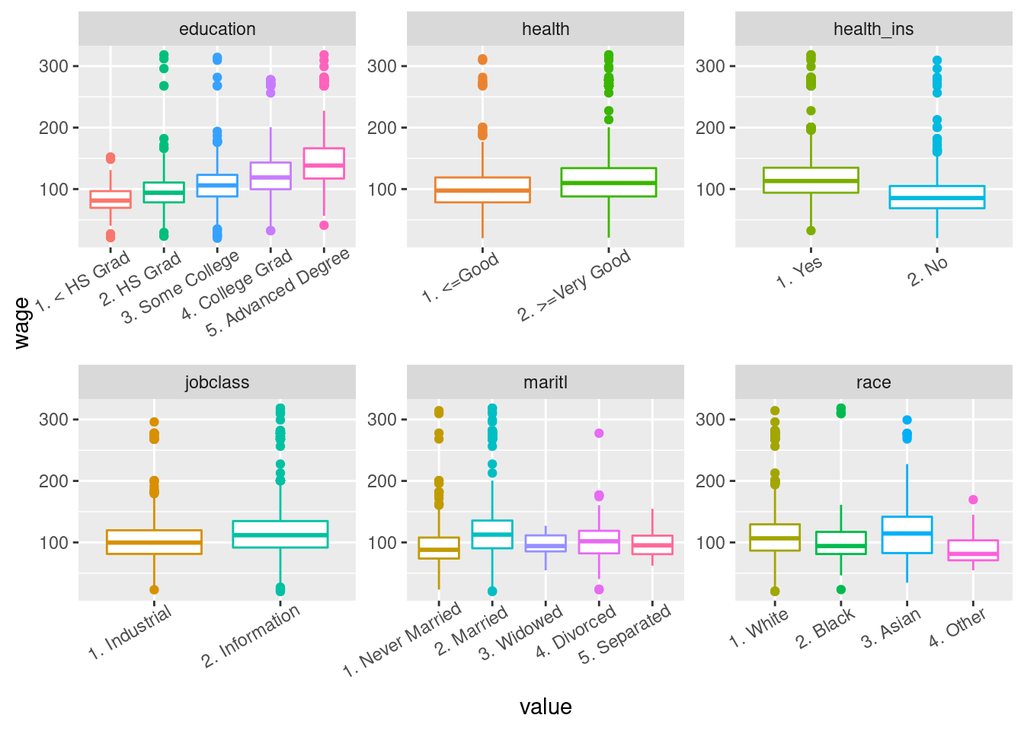

```r
indexes = sapply(train, is.factor)
indexes["wage"] = TRUE
indexes["region"] = FALSE
train[,indexes]%>%
  gather(-wage, key = "var", value = "value") %>%
  ggplot(aes(x = value, y = wage, color = value)) +
  geom_boxplot() +
  facet_wrap(~ var, scales = "free")+
  theme(axis.text.x = element_text(angle = 30, hjust = 0.85),legend.position="none")
```

### Korelasyon Analizi

```r
cor(test[c(1,2,9,10)])
```

```
##               year        age    logwage      wage
## year    1.00000000 0.01344111 0.05258159 0.0539163
## age     0.01344111 1.00000000 0.26720852 0.2544456
## logwage 0.05258159 0.26720852 1.00000000 0.9564424
## wage    0.05391630 0.25444558 0.95644239 1.0000000
```

Sayısal değişkenlerin korelasyon değerleri incelendiğinde bağımlı değişken wage ile year değişkeni arasında (0.05) korelasyon bulunmamaktadır. Year değişkeni sayısal bir değişken olmasına rağmen kategorik davranan bir değişken olarak dikkat çekmektedir. Belki bu değişkeni kategorik olarak kullanmak bir değişikliğe sebep olabilir. İlerleyen bölümlerde bu ihtimal dikkate alınacaktır. Bağımlı değişken wage ile bağımsız değişken age arasında oldukça az(0.25) pozitif bir korelasyon bulunduğu saptanmıştır.

## İlk Model

```
##
## Call:
## lm(formula = wage ~ year + age + maritl + race + education +
##     jobclass + health + health_ins, data = train)
##
## Residuals:
##      Min       1Q   Median       3Q      Max
## -100.256  -19.018   -3.198   13.194  212.273
##
## Coefficients:
##                               Estimate Std. Error t value Pr(>|t|)
## (Intercept)                 -2.794e+03  7.278e+02  -3.839 0.000127 ***
## year                         1.427e+00  3.629e-01   3.933 8.65e-05 ***
## age                          2.220e-01  7.318e-02   3.034 0.002442 **
## maritl2. Married             1.726e+01  2.045e+00   8.439  < 2e-16 ***
## maritl3. Widowed            -1.767e-01  8.681e+00  -0.020 0.983761
## maritl4. Divorced            3.596e+00  3.393e+00   1.060 0.289356
## maritl5. Separated           8.513e+00  5.541e+00   1.536 0.124584
## race2. Black                -4.499e+00  2.486e+00  -1.810 0.070400 .
## race3. Asian                -1.694e+00  3.007e+00  -0.563 0.573299
## race4. Other                -5.812e+00  6.771e+00  -0.858 0.390802
## education2. HS Grad          7.700e+00  2.779e+00   2.771 0.005634 **
## education3. Some College     1.844e+01  2.971e+00   6.207 6.44e-10 ***
## education4. College Grad     3.079e+01  2.991e+00  10.294  < 2e-16 ***
## education5. Advanced Degree  5.302e+01  3.322e+00  15.958  < 2e-16 ***
## jobclass2. Information       3.559e+00  1.562e+00   2.279 0.022784 *
## health2. >=Very Good         7.240e+00  1.671e+00   4.333 1.54e-05 ***
## health_ins2. No             -1.907e+01  1.674e+00 -11.389  < 2e-16 ***
## ---
## Signif. codes:  0 '***' 0.001 '**' 0.01 '*' 0.05 '.' 0.1 ' ' 1
##
## Residual standard error: 34.69 on 2233 degrees of freedom
## Multiple R-squared:  0.3347, Adjusted R-squared:   0.33
## F-statistic: 70.22 on 16 and 2233 DF,  p-value: < 2.2e-16
```

**Model Geçerliliği F Hipotez Testi**

Ho : Bağımlı değişken ve bağımsız değişkenler arasında doğrusal bir ilişki bulunmamaktadır.

Ha : Bağımlı değişken ile en az bir bağımsız değişken arasında doğrusal bir ilişki bulunmaktadır. (Bi != 0)

Varyans analizine göre oluşturulan modelin F istatistiği 70.22 olarak saptanmıştır. F istatistiğinin p değeri 0.05 önem düzeyinden küçük olduğu için %95 güven düzeyinde Ho reddetmek için yeterli kanıta sahip olduğumuz söylenebilir. En az bir kat sayı model için anlamlıdır.

**Regresyon Katsayılarının Anlamlılığına İlişkin Hipotez Testi**

Ho : Eğim katsayısı 0’dan önemli ölçüde farklı değildir.

Ha : Eğim katsayısı 0’dan önemli ölçüde farklıdır.

year, age, maritl2. Married, education faktörünün tüm levelları, jobclass, health ve health insurance

## VIF

```
##                GVIF Df GVIF^(1/(2*Df))
## year       1.008486  1        1.004234
## age        1.358470  1        1.165534
## maritl     1.351396  4        1.038360
## race       1.097152  3        1.015573
## education  1.267915  4        1.030116
## jobclass   1.138946  1        1.067214
## health     1.080316  1        1.039382
## health_ins 1.098150  1        1.047927
```

Modelin VIF değerleri incelendiğinde hiçbir bağımsız değişkenin VIF değeri 5’ten büyük çıkmadığı için modelde herhangi bir bağlantı problemi bulunmamaktadır.

## Olası en iyi Alt Küme Değişken Seçimi

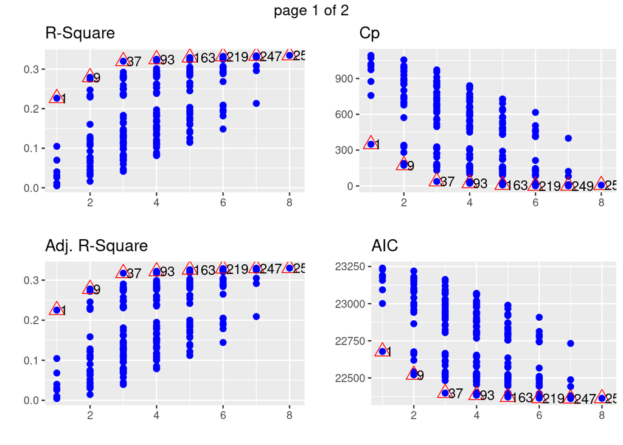

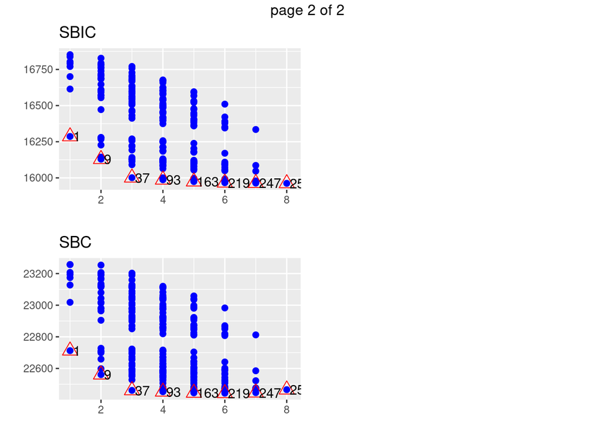

```
## 219. Model:  year age maritl education health health_ins
```

```
## 247. Model:  year age maritl education jobclass health health_ins
```

```
## 248. Model:  year age maritl race education health health_ins
```